# Risk Factor Analysis

## Outcome Variable

**Outcome Variable:** stunted

## Predictor Variables

**Intervention Variable:** fhtcm

**Adjustment Set:**

unadjusted

## Stratifying Variables

The analysis was stratified on these variable(s):

- agecat
- studyid
- country

## Data Summary

| agecat | studyid | country | A | n | nA | nAY0 | nAY1 |
| --- | --- | --- | --- | --- | --- | --- | --- |
| Birth | ki1101329-Keneba | GAMBIA | [160-170) | 1165 | 631 | 598 | 33 |
| Birth | ki1101329-Keneba | GAMBIA | <160 | 1165 | 27 | 24 | 3 |
| Birth | ki1101329-Keneba | GAMBIA | >=170 | 1165 | 507 | 485 | 22 |
| Birth | ki1135781-COHORTS | GUATEMALA | [160-170) | 91 | 53 | 51 | 2 |
| Birth | ki1135781-COHORTS | GUATEMALA | <160 | 91 | 32 | 30 | 2 |
| Birth | ki1135781-COHORTS | GUATEMALA | >=170 | 91 | 6 | 4 | 2 |
| 3 months | ki1000304b-SAS-FoodSuppl | INDIA | [160-170) | 92 | 59 | 40 | 19 |
| 3 months | ki1000304b-SAS-FoodSuppl | INDIA | <160 | 92 | 22 | 11 | 11 |
| 3 months | ki1000304b-SAS-FoodSuppl | INDIA | >=170 | 92 | 11 | 6 | 5 |
| 3 months | ki1101329-Keneba | GAMBIA | [160-170) | 1562 | 859 | 719 | 140 |
| 3 months | ki1101329-Keneba | GAMBIA | <160 | 1562 | 36 | 30 | 6 |
| 3 months | ki1101329-Keneba | GAMBIA | >=170 | 1562 | 667 | 595 | 72 |
| 3 months | ki1135781-COHORTS | GUATEMALA | [160-170) | 140 | 75 | 53 | 22 |
| 3 months | ki1135781-COHORTS | GUATEMALA | <160 | 140 | 53 | 25 | 28 |
| 3 months | ki1135781-COHORTS | GUATEMALA | >=170 | 140 | 12 | 7 | 5 |
| 6 months | ki1000304b-SAS-FoodSuppl | INDIA | [160-170) | 94 | 60 | 33 | 27 |
| 6 months | ki1000304b-SAS-FoodSuppl | INDIA | <160 | 94 | 23 | 9 | 14 |
| 6 months | ki1000304b-SAS-FoodSuppl | INDIA | >=170 | 94 | 11 | 5 | 6 |
| 6 months | ki1101329-Keneba | GAMBIA | [160-170) | 1511 | 828 | 692 | 136 |
| 6 months | ki1101329-Keneba | GAMBIA | <160 | 1511 | 34 | 29 | 5 |
| 6 months | ki1101329-Keneba | GAMBIA | >=170 | 1511 | 649 | 581 | 68 |
| 6 months | ki1135781-COHORTS | GUATEMALA | [160-170) | 151 | 86 | 48 | 38 |
| 6 months | ki1135781-COHORTS | GUATEMALA | <160 | 151 | 54 | 20 | 34 |
| 6 months | ki1135781-COHORTS | GUATEMALA | >=170 | 151 | 11 | 6 | 5 |
| 9 months | ki1000304b-SAS-FoodSuppl | INDIA | [160-170) | 84 | 54 | 18 | 36 |
| 9 months | ki1000304b-SAS-FoodSuppl | INDIA | <160 | 84 | 22 | 5 | 17 |
| 9 months | ki1000304b-SAS-FoodSuppl | INDIA | >=170 | 84 | 8 | 4 | 4 |
| 9 months | ki1101329-Keneba | GAMBIA | [160-170) | 1529 | 840 | 651 | 189 |
| 9 months | ki1101329-Keneba | GAMBIA | <160 | 1529 | 35 | 27 | 8 |
| 9 months | ki1101329-Keneba | GAMBIA | >=170 | 1529 | 654 | 583 | 71 |
| 9 months | ki1135781-COHORTS | GUATEMALA | [160-170) | 164 | 87 | 30 | 57 |
| 9 months | ki1135781-COHORTS | GUATEMALA | <160 | 164 | 65 | 14 | 51 |
| 9 months | ki1135781-COHORTS | GUATEMALA | >=170 | 164 | 12 | 4 | 8 |
| 12 months | ki1000304b-SAS-FoodSuppl | INDIA | [160-170) | 91 | 59 | 11 | 48 |
| 12 months | ki1000304b-SAS-FoodSuppl | INDIA | <160 | 91 | 23 | 5 | 18 |
| 12 months | ki1000304b-SAS-FoodSuppl | INDIA | >=170 | 91 | 9 | 2 | 7 |
| 12 months | ki1101329-Keneba | GAMBIA | [160-170) | 1448 | 805 | 552 | 253 |
| 12 months | ki1101329-Keneba | GAMBIA | <160 | 1448 | 32 | 24 | 8 |
| 12 months | ki1101329-Keneba | GAMBIA | >=170 | 1448 | 611 | 495 | 116 |
| 12 months | ki1135781-COHORTS | GUATEMALA | [160-170) | 204 | 112 | 30 | 82 |
| 12 months | ki1135781-COHORTS | GUATEMALA | <160 | 204 | 78 | 13 | 65 |
| 12 months | ki1135781-COHORTS | GUATEMALA | >=170 | 204 | 14 | 3 | 11 |
| 18 months | ki1000304b-SAS-FoodSuppl | INDIA | [160-170) | 83 | 54 | 6 | 48 |
| 18 months | ki1000304b-SAS-FoodSuppl | INDIA | <160 | 83 | 21 | 2 | 19 |
| 18 months | ki1000304b-SAS-FoodSuppl | INDIA | >=170 | 83 | 8 | 1 | 7 |
| 18 months | ki1101329-Keneba | GAMBIA | [160-170) | 1445 | 823 | 486 | 337 |
| 18 months | ki1101329-Keneba | GAMBIA | <160 | 1445 | 30 | 16 | 14 |
| 18 months | ki1101329-Keneba | GAMBIA | >=170 | 1445 | 592 | 453 | 139 |
| 18 months | ki1135781-COHORTS | GUATEMALA | [160-170) | 188 | 106 | 13 | 93 |
| 18 months | ki1135781-COHORTS | GUATEMALA | <160 | 188 | 68 | 9 | 59 |
| 18 months | ki1135781-COHORTS | GUATEMALA | >=170 | 188 | 14 | 4 | 10 |
| 24 months | ki1101329-Keneba | GAMBIA | [160-170) | 1297 | 729 | 428 | 301 |
| 24 months | ki1101329-Keneba | GAMBIA | <160 | 1297 | 27 | 15 | 12 |
| 24 months | ki1101329-Keneba | GAMBIA | >=170 | 1297 | 541 | 405 | 136 |
| 24 months | ki1135781-COHORTS | GUATEMALA | [160-170) | 240 | 135 | 19 | 116 |
| 24 months | ki1135781-COHORTS | GUATEMALA | <160 | 240 | 89 | 12 | 77 |
| 24 months | ki1135781-COHORTS | GUATEMALA | >=170 | 240 | 16 | 5 | 11 |

The following strata were considered:

- agecat: 12 months, studyid: ki1000304b-SAS-FoodSuppl, country: INDIA
- agecat: 12 months, studyid: ki1101329-Keneba, country: GAMBIA
- agecat: 12 months, studyid: ki1135781-COHORTS, country: GUATEMALA
- agecat: 18 months, studyid: ki1000304b-SAS-FoodSuppl, country: INDIA
- agecat: 18 months, studyid: ki1101329-Keneba, country: GAMBIA
- agecat: 18 months, studyid: ki1135781-COHORTS, country: GUATEMALA
- agecat: 24 months, studyid: ki1101329-Keneba, country: GAMBIA
- agecat: 24 months, studyid: ki1135781-COHORTS, country: GUATEMALA
- agecat: 3 months, studyid: ki1000304b-SAS-FoodSuppl, country: INDIA
- agecat: 3 months, studyid: ki1101329-Keneba, country: GAMBIA
- agecat: 3 months, studyid: ki1135781-COHORTS, country: GUATEMALA
- agecat: 6 months, studyid: ki1000304b-SAS-FoodSuppl, country: INDIA
- agecat: 6 months, studyid: ki1101329-Keneba, country: GAMBIA
- agecat: 6 months, studyid: ki1135781-COHORTS, country: GUATEMALA
- agecat: 9 months, studyid: ki1000304b-SAS-FoodSuppl, country: INDIA
- agecat: 9 months, studyid: ki1101329-Keneba, country: GAMBIA
- agecat: 9 months, studyid: ki1135781-COHORTS, country: GUATEMALA
- agecat: Birth, studyid: ki1101329-Keneba, country: GAMBIA
- agecat: Birth, studyid: ki1135781-COHORTS, country: GUATEMALA

### Dropped Strata

Some strata were dropped due to rare outcomes:

- agecat: Birth, studyid: ki1101329-Keneba, country: GAMBIA
- agecat: Birth, studyid: ki1135781-COHORTS, country: GUATEMALA
- agecat: 9 months, studyid: ki1000304b-SAS-FoodSuppl, country: INDIA
- agecat: 9 months, studyid: ki1135781-COHORTS, country: GUATEMALA
- agecat: 12 months, studyid: ki1000304b-SAS-FoodSuppl, country: INDIA
- agecat: 12 months, studyid: ki1135781-COHORTS, country: GUATEMALA
- agecat: 18 months, studyid: ki1000304b-SAS-FoodSuppl, country: INDIA
- agecat: 18 months, studyid: ki1135781-COHORTS, country: GUATEMALA

## Methods Detail

We’re interested in the causal parameters $E[Y_a]$ for all values of $a \in \mathcal{A}$. These parameters represent the mean outcome if, possibly contrary to fact, we intervened to set all units to have $A=a$. Under the randomization and positivity assumptions, these are identified by the statistical parameters $\psi_a=E_W[E_{Y|A,W}(Y|A=a,W)]$. In addition, we’re interested in the mean of $Y$, $E[Y]$ under no intervention (the observed mean). We will estimate these parameters by using SuperLearner to fit the relevant likelihood factors – $E_{Y|A,W}(Y|A=a,W)$ and $p(A=a|W)$, and then updating our likelihood fit using a joint TMLE.

For unadjusted analyses ($W=\{\}$), initial likelihoods were estimated using Lrnr_glm to estimate the simple $E(Y|A)$ and Lrnr_mean to estimate $p(A)$. For adjusted analyses, a small library containing Lrnr_glmnet, Lrnr_xgboost, and Lrnr_mean was used.

Having estimated these parameters, we will then use the delta method to estimate relative risks and attributable risks relative to a prespecified baseline level of $A$.

# Results Detail

## Results Plots

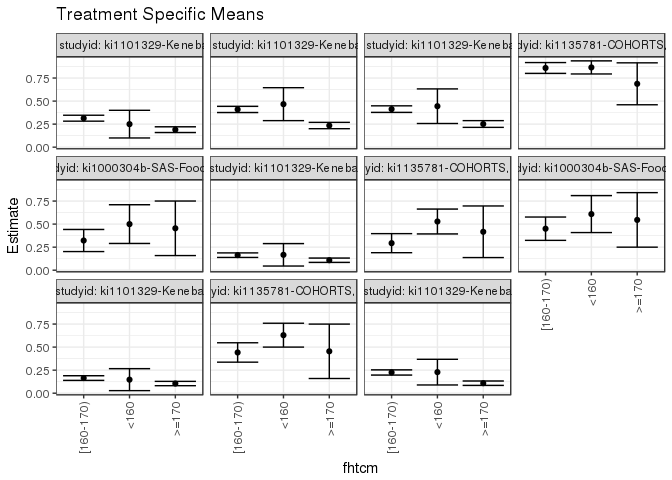

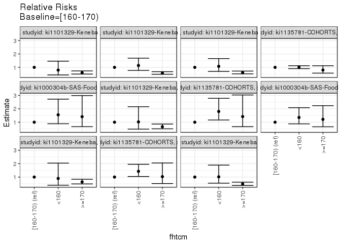

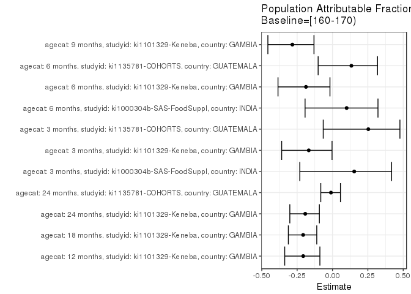

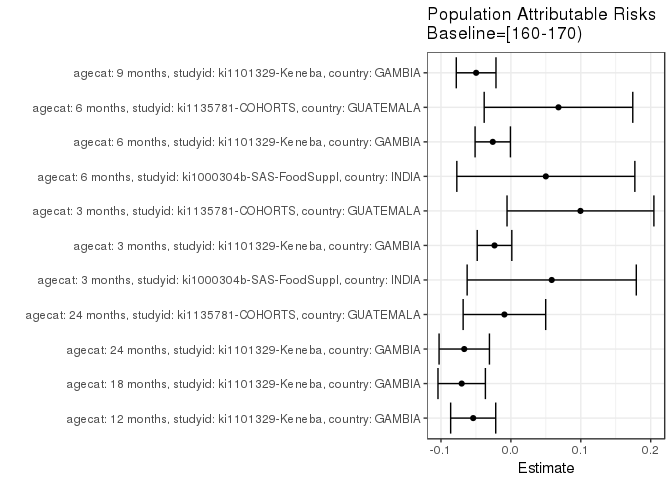

## Results Table

### Parameter: TSM

| agecat | studyid | country | intervention_level | baseline_level | estimate | ci_lower | ci_upper |
| --- | --- | --- | --- | --- | --- | --- | --- |
| 3 months | ki1000304b-SAS-FoodSuppl | INDIA | [160-170) | NA | 0.3220339 | 0.2021530 | 0.4419148 |
| 3 months | ki1000304b-SAS-FoodSuppl | INDIA | <160 | NA | 0.5000000 | 0.2899223 | 0.7100777 |
| 3 months | ki1000304b-SAS-FoodSuppl | INDIA | >=170 | NA | 0.4545455 | 0.1586809 | 0.7504100 |
| 3 months | ki1101329-Keneba | GAMBIA | [160-170) | NA | 0.1629802 | 0.1382729 | 0.1876875 |
| 3 months | ki1101329-Keneba | GAMBIA | <160 | NA | 0.1666667 | 0.0448884 | 0.2884449 |
| 3 months | ki1101329-Keneba | GAMBIA | >=170 | NA | 0.1079460 | 0.0843889 | 0.1315032 |
| 3 months | ki1135781-COHORTS | GUATEMALA | [160-170) | NA | 0.2933333 | 0.1899234 | 0.3967432 |
| 3 months | ki1135781-COHORTS | GUATEMALA | <160 | NA | 0.5283019 | 0.3934243 | 0.6631795 |
| 3 months | ki1135781-COHORTS | GUATEMALA | >=170 | NA | 0.4166667 | 0.1367254 | 0.6966079 |
| 6 months | ki1000304b-SAS-FoodSuppl | INDIA | [160-170) | NA | 0.4500000 | 0.3234441 | 0.5765559 |
| 6 months | ki1000304b-SAS-FoodSuppl | INDIA | <160 | NA | 0.6086957 | 0.4081727 | 0.8092186 |
| 6 months | ki1000304b-SAS-FoodSuppl | INDIA | >=170 | NA | 0.5454545 | 0.2496246 | 0.8412845 |
| 6 months | ki1101329-Keneba | GAMBIA | [160-170) | NA | 0.1642512 | 0.1390066 | 0.1894958 |
| 6 months | ki1101329-Keneba | GAMBIA | <160 | NA | 0.1470588 | 0.0279737 | 0.2661439 |
| 6 months | ki1101329-Keneba | GAMBIA | >=170 | NA | 0.1047766 | 0.0812062 | 0.1283470 |
| 6 months | ki1135781-COHORTS | GUATEMALA | [160-170) | NA | 0.4418605 | 0.3365538 | 0.5471671 |
| 6 months | ki1135781-COHORTS | GUATEMALA | <160 | NA | 0.6296296 | 0.5004022 | 0.7588571 |
| 6 months | ki1135781-COHORTS | GUATEMALA | >=170 | NA | 0.4545455 | 0.1593141 | 0.7497768 |
| 9 months | ki1101329-Keneba | GAMBIA | [160-170) | NA | 0.2250000 | 0.1967517 | 0.2532483 |
| 9 months | ki1101329-Keneba | GAMBIA | <160 | NA | 0.2285714 | 0.0894113 | 0.3677316 |
| 9 months | ki1101329-Keneba | GAMBIA | >=170 | NA | 0.1085627 | 0.0847128 | 0.1324126 |
| 12 months | ki1101329-Keneba | GAMBIA | [160-170) | NA | 0.3142857 | 0.2822057 | 0.3463657 |
| 12 months | ki1101329-Keneba | GAMBIA | <160 | NA | 0.2500000 | 0.0999197 | 0.4000803 |
| 12 months | ki1101329-Keneba | GAMBIA | >=170 | NA | 0.1898527 | 0.1587450 | 0.2209604 |
| 18 months | ki1101329-Keneba | GAMBIA | [160-170) | NA | 0.4094775 | 0.3758704 | 0.4430847 |
| 18 months | ki1101329-Keneba | GAMBIA | <160 | NA | 0.4666667 | 0.2880835 | 0.6452498 |
| 18 months | ki1101329-Keneba | GAMBIA | >=170 | NA | 0.2347973 | 0.2006409 | 0.2689537 |
| 24 months | ki1101329-Keneba | GAMBIA | [160-170) | NA | 0.4128944 | 0.3771400 | 0.4486488 |
| 24 months | ki1101329-Keneba | GAMBIA | <160 | NA | 0.4444444 | 0.2569423 | 0.6319466 |
| 24 months | ki1101329-Keneba | GAMBIA | >=170 | NA | 0.2513863 | 0.2148170 | 0.2879556 |
| 24 months | ki1135781-COHORTS | GUATEMALA | [160-170) | NA | 0.8592593 | 0.8004752 | 0.9180434 |
| 24 months | ki1135781-COHORTS | GUATEMALA | <160 | NA | 0.8651685 | 0.7940626 | 0.9362745 |
| 24 months | ki1135781-COHORTS | GUATEMALA | >=170 | NA | 0.6875000 | 0.4599085 | 0.9150915 |

### Parameter: E(Y)

| agecat | studyid | country | intervention_level | baseline_level | estimate | ci_lower | ci_upper |
| --- | --- | --- | --- | --- | --- | --- | --- |
| 3 months | ki1000304b-SAS-FoodSuppl | INDIA | NA | NA | 0.3804348 | 0.3641754 | 0.3966941 |
| 3 months | ki1101329-Keneba | GAMBIA | NA | NA | 0.1395647 | 0.1382103 | 0.1409190 |
| 3 months | ki1135781-COHORTS | GUATEMALA | NA | NA | 0.3928571 | 0.3744201 | 0.4112941 |
| 6 months | ki1000304b-SAS-FoodSuppl | INDIA | NA | NA | 0.5000000 | 0.4860247 | 0.5139753 |
| 6 months | ki1101329-Keneba | GAMBIA | NA | NA | 0.1383190 | 0.1368455 | 0.1397925 |
| 6 months | ki1135781-COHORTS | GUATEMALA | NA | NA | 0.5099338 | 0.4956325 | 0.5242351 |
| 9 months | ki1101329-Keneba | GAMBIA | NA | NA | 0.1752780 | 0.1723858 | 0.1781701 |
| 12 months | ki1101329-Keneba | GAMBIA | NA | NA | 0.2603591 | 0.2572179 | 0.2635003 |
| 18 months | ki1101329-Keneba | GAMBIA | NA | NA | 0.3391003 | 0.3345992 | 0.3436015 |
| 24 months | ki1101329-Keneba | GAMBIA | NA | NA | 0.3461835 | 0.3418108 | 0.3505562 |
| 24 months | ki1135781-COHORTS | GUATEMALA | NA | NA | 0.8500000 | 0.8444826 | 0.8555174 |

### Parameter: RR

| agecat | studyid | country | intervention_level | baseline_level | estimate | ci_lower | ci_upper |
| --- | --- | --- | --- | --- | --- | --- | --- |
| 3 months | ki1000304b-SAS-FoodSuppl | INDIA | [160-170) | [160-170) | 1.0000000 | 1.0000000 | 1.0000000 |
| 3 months | ki1000304b-SAS-FoodSuppl | INDIA | <160 | [160-170) | 1.5526316 | 0.8856842 | 2.7218108 |
| 3 months | ki1000304b-SAS-FoodSuppl | INDIA | >=170 | [160-170) | 1.4114833 | 0.6668476 | 2.9876165 |
| 3 months | ki1101329-Keneba | GAMBIA | [160-170) | [160-170) | 1.0000000 | 1.0000000 | 1.0000000 |
| 3 months | ki1101329-Keneba | GAMBIA | <160 | [160-170) | 1.0226190 | 0.4848755 | 2.1567386 |
| 3 months | ki1101329-Keneba | GAMBIA | >=170 | [160-170) | 0.6623260 | 0.5077753 | 0.8639169 |
| 3 months | ki1135781-COHORTS | GUATEMALA | [160-170) | [160-170) | 1.0000000 | 1.0000000 | 1.0000000 |
| 3 months | ki1135781-COHORTS | GUATEMALA | <160 | [160-170) | 1.8010292 | 1.1654275 | 2.7832756 |
| 3 months | ki1135781-COHORTS | GUATEMALA | >=170 | [160-170) | 1.4204545 | 0.6651417 | 3.0334757 |
| 6 months | ki1000304b-SAS-FoodSuppl | INDIA | [160-170) | [160-170) | 1.0000000 | 1.0000000 | 1.0000000 |
| 6 months | ki1000304b-SAS-FoodSuppl | INDIA | <160 | [160-170) | 1.3526570 | 0.8771494 | 2.0859399 |
| 6 months | ki1000304b-SAS-FoodSuppl | INDIA | >=170 | [160-170) | 1.2121212 | 0.6579913 | 2.2329139 |
| 6 months | ki1101329-Keneba | GAMBIA | [160-170) | [160-170) | 1.0000000 | 1.0000000 | 1.0000000 |
| 6 months | ki1101329-Keneba | GAMBIA | <160 | [160-170) | 0.8953287 | 0.3926645 | 2.0414717 |
| 6 months | ki1101329-Keneba | GAMBIA | >=170 | [160-170) | 0.6379045 | 0.4857719 | 0.8376815 |
| 6 months | ki1135781-COHORTS | GUATEMALA | [160-170) | [160-170) | 1.0000000 | 1.0000000 | 1.0000000 |
| 6 months | ki1135781-COHORTS | GUATEMALA | <160 | [160-170) | 1.4249513 | 1.0404110 | 1.9516193 |
| 6 months | ki1135781-COHORTS | GUATEMALA | >=170 | [160-170) | 1.0287081 | 0.5150200 | 2.0547561 |
| 9 months | ki1101329-Keneba | GAMBIA | [160-170) | [160-170) | 1.0000000 | 1.0000000 | 1.0000000 |
| 9 months | ki1101329-Keneba | GAMBIA | <160 | [160-170) | 1.0158730 | 0.5455900 | 1.8915266 |
| 9 months | ki1101329-Keneba | GAMBIA | >=170 | [160-170) | 0.4825009 | 0.3746345 | 0.6214246 |
| 12 months | ki1101329-Keneba | GAMBIA | [160-170) | [160-170) | 1.0000000 | 1.0000000 | 1.0000000 |
| 12 months | ki1101329-Keneba | GAMBIA | <160 | [160-170) | 0.7954545 | 0.4326705 | 1.4624244 |
| 12 months | ki1101329-Keneba | GAMBIA | >=170 | [160-170) | 0.6040768 | 0.4980282 | 0.7327070 |
| 18 months | ki1101329-Keneba | GAMBIA | [160-170) | [160-170) | 1.0000000 | 1.0000000 | 1.0000000 |
| 18 months | ki1101329-Keneba | GAMBIA | <160 | [160-170) | 1.1396637 | 0.7705527 | 1.6855866 |
| 18 months | ki1101329-Keneba | GAMBIA | >=170 | [160-170) | 0.5734070 | 0.4852036 | 0.6776447 |
| 24 months | ki1101329-Keneba | GAMBIA | [160-170) | [160-170) | 1.0000000 | 1.0000000 | 1.0000000 |
| 24 months | ki1101329-Keneba | GAMBIA | <160 | [160-170) | 1.0764120 | 0.6997431 | 1.6558401 |
| 24 months | ki1101329-Keneba | GAMBIA | >=170 | [160-170) | 0.6088393 | 0.5140193 | 0.7211505 |
| 24 months | ki1135781-COHORTS | GUATEMALA | [160-170) | [160-170) | 1.0000000 | 1.0000000 | 1.0000000 |
| 24 months | ki1135781-COHORTS | GUATEMALA | <160 | [160-170) | 1.0068772 | 0.9047640 | 1.1205150 |
| 24 months | ki1135781-COHORTS | GUATEMALA | >=170 | [160-170) | 0.8001078 | 0.5706118 | 1.1219054 |

### Parameter: PAR

| agecat | studyid | country | intervention_level | baseline_level | estimate | ci_lower | ci_upper |
| --- | --- | --- | --- | --- | --- | --- | --- |
| 3 months | ki1000304b-SAS-FoodSuppl | INDIA | [160-170) | NA | 0.0584009 | -0.0625776 | 0.1793794 |
| 3 months | ki1101329-Keneba | GAMBIA | [160-170) | NA | -0.0234155 | -0.0481600 | 0.0013289 |
| 3 months | ki1135781-COHORTS | GUATEMALA | [160-170) | NA | 0.0995238 | -0.0055168 | 0.2045644 |
| 6 months | ki1000304b-SAS-FoodSuppl | INDIA | [160-170) | NA | 0.0500000 | -0.0773252 | 0.1773252 |
| 6 months | ki1101329-Keneba | GAMBIA | [160-170) | NA | -0.0259322 | -0.0512198 | -0.0006446 |
| 6 months | ki1135781-COHORTS | GUATEMALA | [160-170) | NA | 0.0680733 | -0.0382000 | 0.1743466 |
| 9 months | ki1101329-Keneba | GAMBIA | [160-170) | NA | -0.0497220 | -0.0781180 | -0.0213261 |
| 12 months | ki1101329-Keneba | GAMBIA | [160-170) | NA | -0.0539266 | -0.0861600 | -0.0216932 |
| 18 months | ki1101329-Keneba | GAMBIA | [160-170) | NA | -0.0703772 | -0.1042844 | -0.0364699 |
| 24 months | ki1101329-Keneba | GAMBIA | [160-170) | NA | -0.0667109 | -0.1027317 | -0.0306901 |
| 24 months | ki1135781-COHORTS | GUATEMALA | [160-170) | NA | -0.0092593 | -0.0683017 | 0.0497832 |

### Parameter: PAF

| agecat | studyid | country | intervention_level | baseline_level | estimate | ci_lower | ci_upper |
| --- | --- | --- | --- | --- | --- | --- | --- |
| 3 months | ki1000304b-SAS-FoodSuppl | INDIA | [160-170) | NA | 0.1535109 | -0.2312738 | 0.4180467 |
| 3 months | ki1101329-Keneba | GAMBIA | [160-170) | NA | -0.1677756 | -0.3593521 | -0.0031985 |
| 3 months | ki1135781-COHORTS | GUATEMALA | [160-170) | NA | 0.2533333 | -0.0655673 | 0.4767941 |
| 6 months | ki1000304b-SAS-FoodSuppl | INDIA | [160-170) | NA | 0.1000000 | -0.1939420 | 0.3215751 |
| 6 months | ki1101329-Keneba | GAMBIA | [160-170) | NA | -0.1874812 | -0.3852746 | -0.0179293 |
| 6 months | ki1135781-COHORTS | GUATEMALA | [160-170) | NA | 0.1334944 | -0.1015114 | 0.3183621 |
| 9 months | ki1101329-Keneba | GAMBIA | [160-170) | NA | -0.2836754 | -0.4569643 | -0.1309971 |
| 12 months | ki1101329-Keneba | GAMBIA | [160-170) | NA | -0.2071239 | -0.3377964 | -0.0892151 |
| 18 months | ki1101329-Keneba | GAMBIA | [160-170) | NA | -0.2075409 | -0.3122270 | -0.1112063 |
| 24 months | ki1101329-Keneba | GAMBIA | [160-170) | NA | -0.1927038 | -0.3017815 | -0.0927658 |
| 24 months | ki1135781-COHORTS | GUATEMALA | [160-170) | NA | -0.0108932 | -0.0828042 | 0.0562419 |